# metacheck

[figure not shown]

Metacheck provides extendable and integrated tools for automatically checking research outputs for best practices. (formerly named papercheck)

Inspired by practices in software development, where automated checks (e.g., CRAN checks for R packages) are used to identify issues before release, metacheck aims to screen scientific manuscripts to identify potential issues or areas for improvement and guide researchers in adopting best practices. It can also assist with processing large numbers of papers for metascientific enquiry.

See Get Started for the basics, Articles for more detailed examples of what you can do, or our introductory blog post for a more conceptual overview.

## The Team

Metacheck was initially developed by Lisa and Daniël in 2024 during Lisa’s visiting professorship at the Eindhoven Artificial Intelligence Systems Institute ([EAISI](https://www.tue.nl/en/research/institutes/eindhoven-artificial-intelligence-systems-institute)).

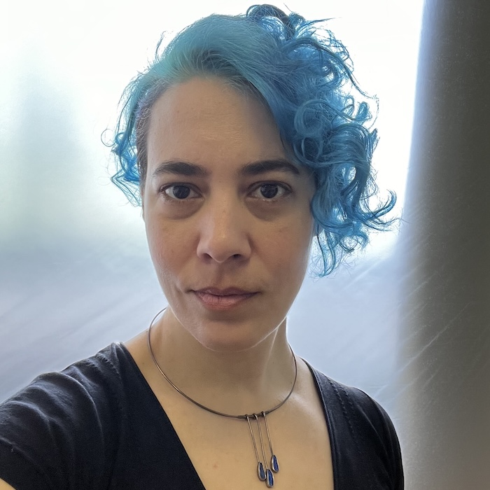

Lisa DeBruine

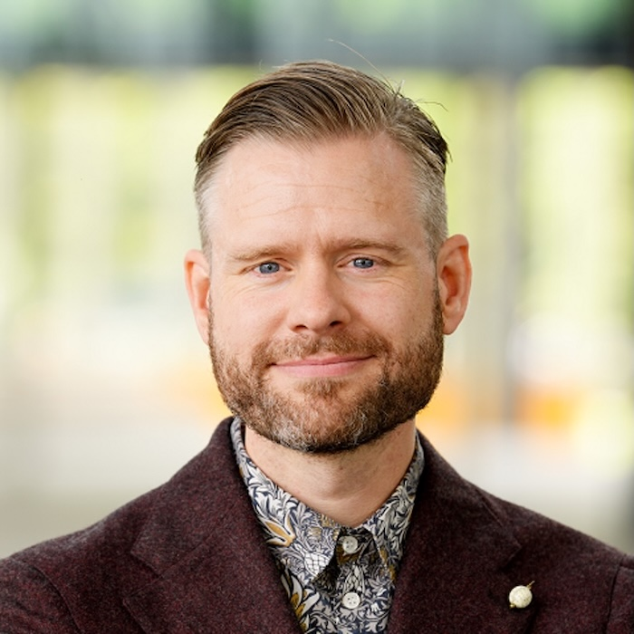

Daniël Lakens

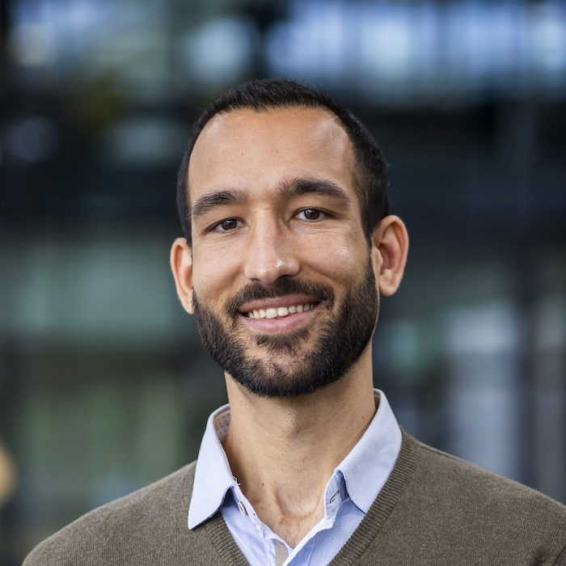

Cristian Mesquida

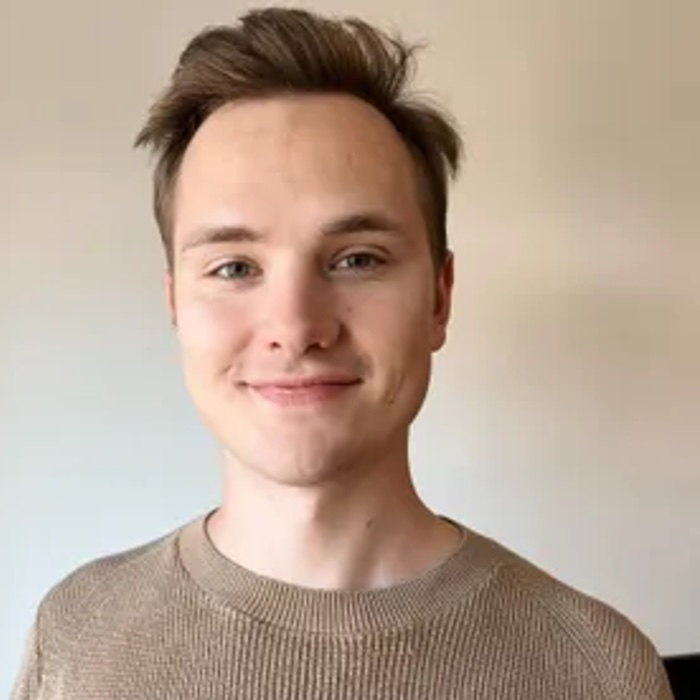

Jakub Werner

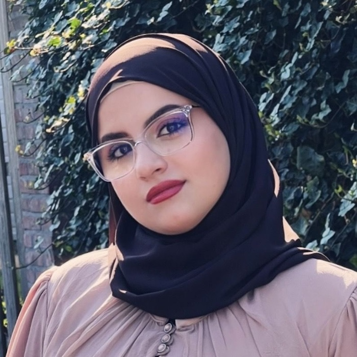

Hadeel Khawatmy

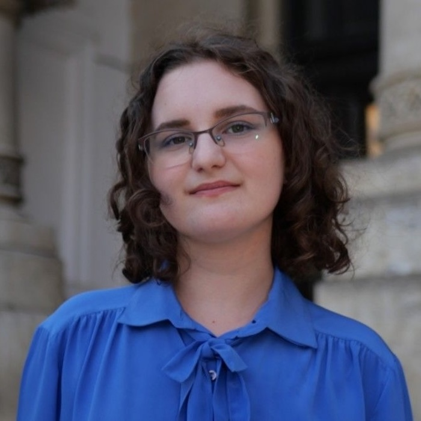

Lavinia Ion

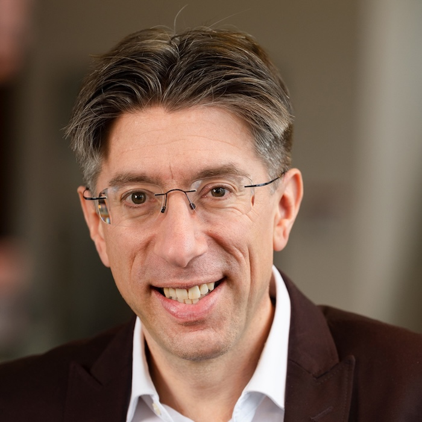

René Bekkers

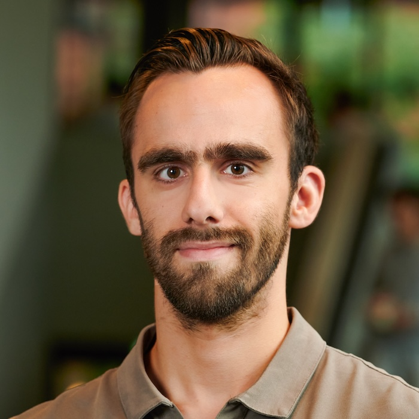

Max Littel